# Student Lunch Spending

Jiahua Huang

This visual story explores how student lunch spending changes depending on weekdays, meal types, and where student get lunches. The data was collected through survey using a Google Form.

## Spending Categories

Lunch spending was divided into three categories based on price:

- **Cheap:** less than $10
- **Moderate:** between $10 and $20
- **Expensive:** more than $20

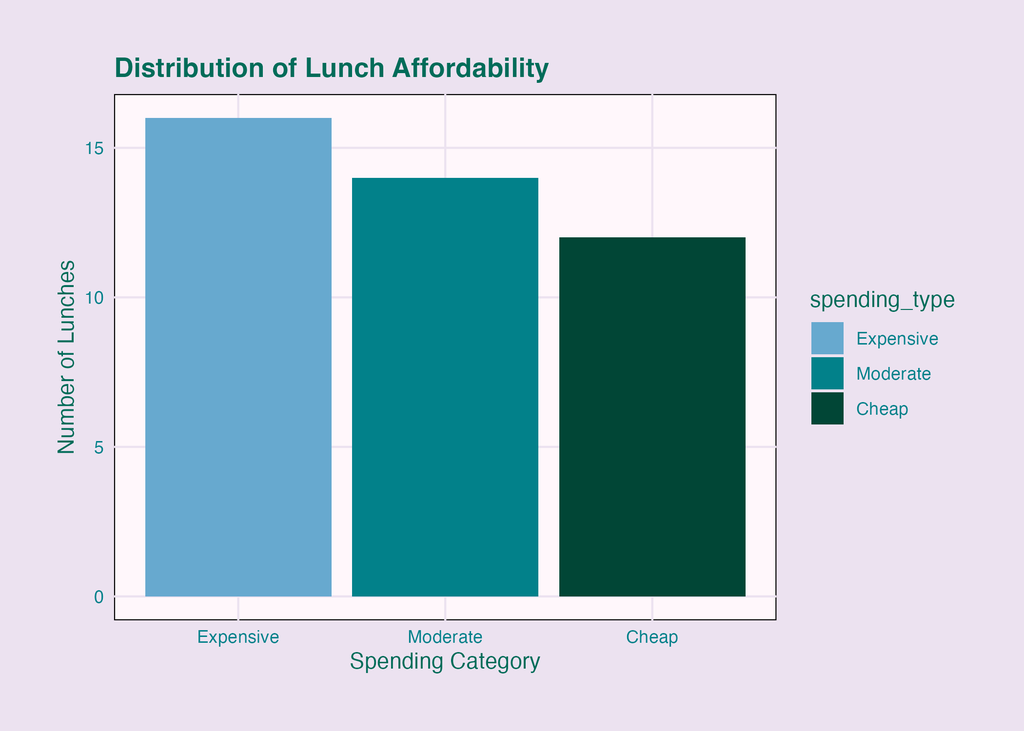

A surprisingly large number of students fall into the expensive spending category, while fewer students consistently purchase cheap lunches.

This suggests that many students are willing to spend a relatively high amount on lunch.

## Spending Across Weekdays

Average lunch spending changes slightly throughout the week.

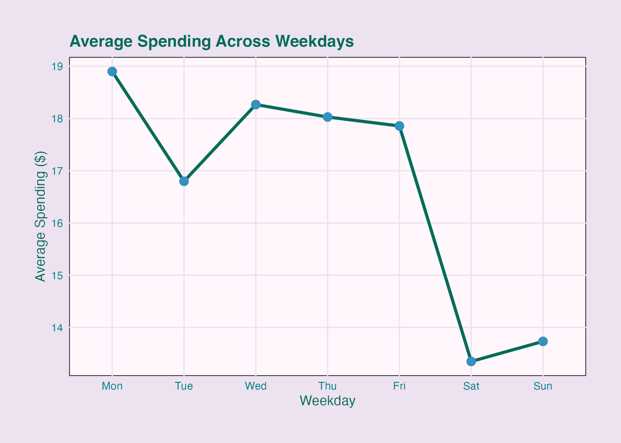

In general, spending appears to be higher on weekdays than on weekends. One possible explanation is that students are more likely to purchase food on campus during weekdays, while choosing to eat at home during weekends.

## Do Spending Habits Change Across Weekdays?

Looking at the proportions of cheap, moderate, and expensive lunches across weekdays shows a more detailed pattern.

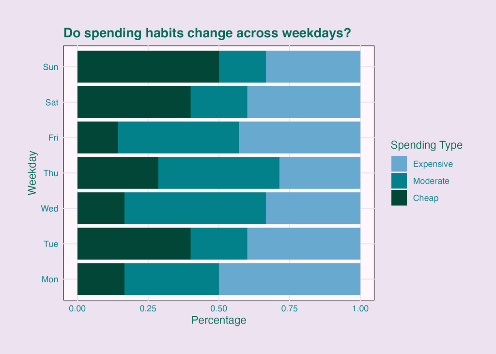

Some weekdays, such as Monday, contain a larger proportion of expensive lunches, whereas days like Sunday are dominated by cheaper or more moderate spending choices.

This pattern is consistent with the previous graph, providing further evidence that students tend to spend more on lunch during weekdays compared with weekends.

## Do Rice Meals Affect Spending?

This boxplot compares spending for rice meals and non-rice meals.

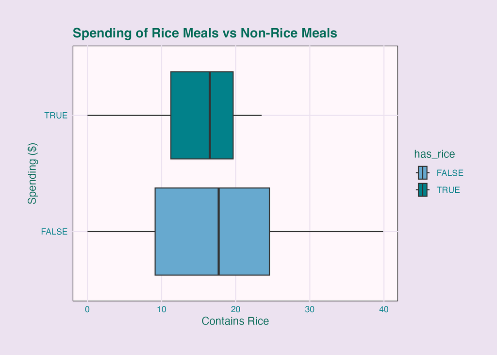

Rice meals appear to have a lower average cost than non-rice meals and also show less variation in spending. This may suggest that rice-based meals are generally more affordable and consistent in price.

## Lunch Source and Spending

This visualisation compares spending distributions according to where students obtained their lunch.

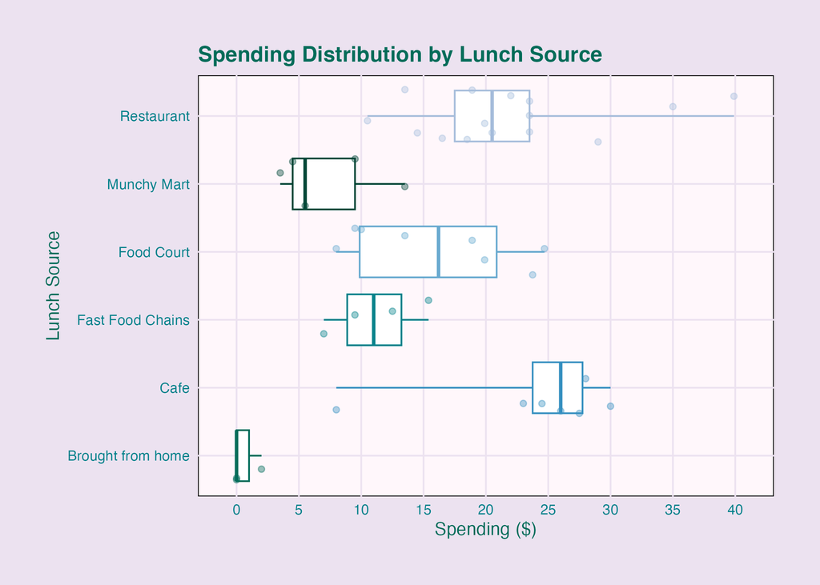

Students who bought lunch from Restaurants and Cafes generally spent the most, while those who brought from home spent the least. Fast Food Chains, Food Courts, and Munchy Mart show more moderate spending levels.

Overall, the analysis shows that student lunch spending is influenced by several factors, including weekdays, meal type, and lunch source. Students generally spend more during weekdays, possibly due to being on campus. Rice meals tend to be cheaper and more consistent in price, while restaurant and café purchases are associated with higher spending.